# Topic 8 Exercises: Tree-based models

## Question 8.4.1

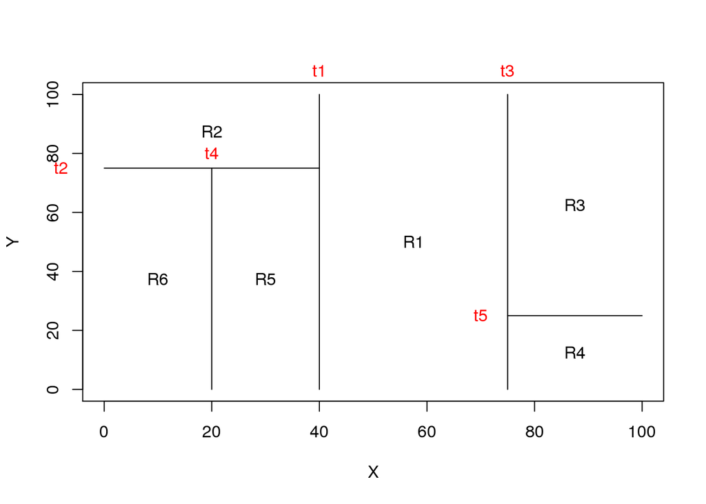

```r
par(xpd = NA)
plot(NA, NA, type = "n", xlim = c(0, 100), ylim = c(0, 100), xlab = "X", ylab = "Y")

lines(x = c(40, 40), y = c(0, 100))
text(x = 40, y = 108, labels = c("t1"), col = "red")

lines(x = c(0, 40), y = c(75, 75))
text(x = -8, y = 75, labels = c("t2"), col = "red")

lines(x = c(75, 75), y = c(0, 100))
text(x = 75, y = 108, labels = c("t3"), col = "red")

lines(x = c(20, 20), y = c(0, 75))
text(x = 20, y = 80, labels = c("t4"), col = "red")

lines(x = c(75, 100), y = c(25, 25))
text(x = 70, y = 25, labels = c("t5"), col = "red")

text(x = (40 + 75)/2, y = 50, labels = c("R1"))

text(x = 20, y = (100 + 75)/2, labels = c("R2"))

text(x = (75 + 100)/2, y = (100 + 25)/2, labels = c("R3"))

text(x = (75 + 100)/2, y = 25/2, labels = c("R4"))

text(x = 30, y = 75/2, labels = c("R5"))

text(x = 10, y = 75/2, labels = c("R6"))
```

## Question 8.4.2

To begin, we can let fhat(x) = 0 and ri = yi. fhat(x) will equal to 1/lambda * f1*(x1). If we left fhat(x) = lambdafhat1(x) and ri = yi-lambda*fhat1(xi) then we ’ll get that fhat2(x) will also equal 1/lambdaf2(x2). To maximize this, we know that fhat(x) = lambdafhat1(x) + lambdafhat2(x) and that ri = yi - lambdafhat1(x) - lambdafhat2(x) which gets us to our model of the form.

## Question 8.4.3

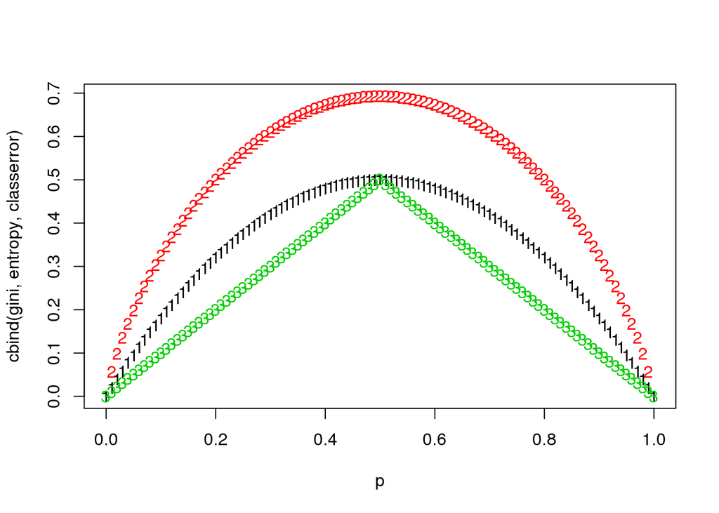

```r
p = seq(0,1,0.01)
gini = p * (1-p) * 2
entropy = -(p*log(p) + (1-p) * log(1-p))
classerror = 1-pmax(p, 1-p)
matplot(p, cbind(gini,entropy,classerror))
```

The red curve is entropy. The black curve is gini index and the green curve is class error.

## Question 8.4.4

1. I can’t sketch it out on R, but the branching would display that if X1 >= 1, then 5 otherwise X2 >= 1 then 15. If X1 < 0 then 3, otherwise X2 <0 is 10 else all is 0.

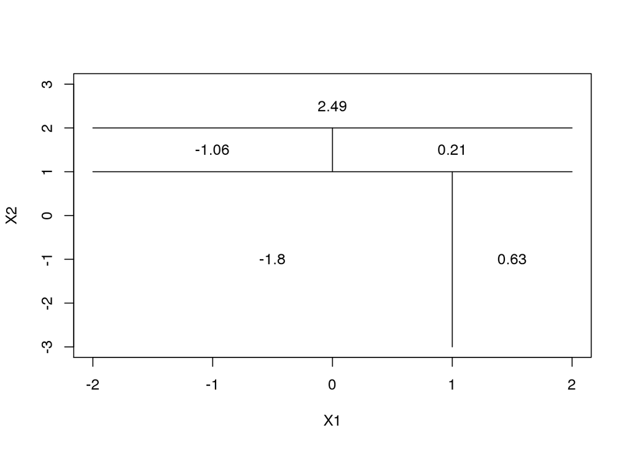

```r
par(xpd = NA)
plot(NA, NA, type = "n", xlim = c(-2, 2), ylim = c(-3, 3), xlab = "X1", ylab = "X2")

lines(x = c(-2, 2), y = c(1, 1))

lines(x = c(1, 1), y = c(-3, 1))
text(x = (-2 + 1)/2, y = -1, labels = c(-1.8))

text(x = 1.5, y = -1, labels = c(0.63))

lines(x = c(-2, 2), y = c(2, 2))
text(x = 0, y = 2.5, labels = c(2.49))

lines(x = c(0, 0), y = c(1, 2))
text(x = -1, y = 1.5, labels = c(-1.06))

text(x = 1, y = 1.5, labels = c(0.21))
```

## Question 8.4.5

With the majority vote approach, red would be more likely because based on the data given, there are 6 data points that show the probability of red being 50% or higher. So red would be 6/10, and have the majority compared to green. However, with the average probability, it would be green because when you average the data given, you get a probability of 0.45 which is less than 50% so it wouldn’t be red but instead be green.

## Question 8.4.12

```r
library(dplyr)
library(ISLR)
set.seed(1)
df <- tbl_df(College)
N <- dim(df)[1]
p <- dim(df)[2]-1
train_sample <- sample(1:N, 2*N/3)
train <- df[train_sample,]
test <- df[-train_sample,]
```

Boosting

```r
library(gbm)
lambdas <- seq(0.2, 4, by = 0.1)
test_errors <- sapply(lambdas, function(i){
  boost <- gbm(train$Grad.Rate ~ ., data = train, distribution = "gaussian", n.trees = 50, shrinkage = lambdas[i])
  test_pred <- predict(boost, test, n.trees=50)
  mean((test$Grad.Rate - test_pred)^2)
})

min(test_errors)
```

```
## [1] 188.0453
```

```r
lambdas[which.min(test_errors)]
```

```
## [1] 2.2
```

Bagging

```r
library(randomForest)
bagging <- randomForest(train$Grad.Rate ~.,data = train, importance = T, mtry = p, ntree = 500)
bagpred <- predict(bagging,test)
mean((bagpred-test$Grad.Rate)^2)
```

```
## [1] 196.4822
```

Random Forests

```r
MSE_list <- sapply(1:(p-1), function(i){
  ranFor <- randomForest(train$Grad.Rate ~ ., data = train, importance = T, mtry = i, ntree = 500)
  ranForpred <- predict(ranFor, test)
  mean((ranForpred - test$Grad.Rate)^2)
})

minNbrTrees <- which.min(MSE_list)
minNbrTrees
```

```
## [1] 8
```

```r
min(MSE_list)
```

```
## [1] 195.5799
```

Linear Regression

```r
mod1 <- lm(Grad.Rate ~ ., data = train)
modpred <- predict(mod1, test)
mean((modpred - test$Grad.Rate)^2)
```

```
## [1] 187.9116
```